# Factors with `forcats`

Felix Lennert

knit on 2020-06-22

# Introduction

Factors are used in R to represent categorical data. In the following, I will briefly introduce you to the `forcats` package (nice anagram, Hadley!). Factors are augmented vectors which build upon integers. If you want to learn more about them, consider reading [this paper](https://peerj.com/preprints/3163/).

```r
library(tidyverse) # forcats is part of the tidyverse, so no need to load it separately
```

# Creating a factor

You can create a factor in two manners.

1. Take a character vector and coerce it to a factor

```r
parties <- c("AfD", "CDU", "CSU", "FDP", "Greens", "Leftists", "SPD")
parties_fct <- as_factor(parties)

typeof(parties_fct)
```

```
## [1] "integer"
```

2. Create it from scratch by providing levels and a vector respectively

```r
party_sample <- c(sample(parties, 8, replace = TRUE), "CUD")
factor(party_sample, levels = parties)
```

```
## [1] AfD    FDP    Greens CSU    AfD    Greens AfD    FDP    <NA>
## Levels: AfD CDU CSU FDP Greens Leftists SPD
```

If you want to access the levels, use `levels()`

```r
levels(parties_fct)
```

```
## [1] "AfD"      "CDU"      "CSU"      "FDP"      "Greens"   "Leftists" "SPD"
```

# Some basic operations

I will have a further look into factors using data on the presidential elections in the U.S.

```r
election_data <- read_csv("data/pres16results.csv") %>%
  drop_na() %>%
  glimpse()
```

```
## Rows: 18,007
## Columns: 9
## $ county      <chr> "Los Angeles County", "Los Angeles County", "Los Angeles …
## $ fips        <chr> "6037", "6037", "6037", "6037", "6037", "17031", "17031",…
## $ cand        <chr> "Hillary Clinton", "Donald Trump", "Gary Johnson", "Jill …
## $ st          <chr> "CA", "CA", "CA", "CA", "CA", "IL", "IL", "IL", "IL", "TX…
## $ pct_report  <dbl> 1.0000, 1.0000, 1.0000, 1.0000, 1.0000, 0.9746, 0.9746, 0…
## $ votes       <dbl> 1654626, 542591, 56905, 46682, 13471, 1528582, 440213, 55…
## $ total_votes <dbl> 2314275, 2314275, 2314275, 2314275, 2314275, 2055215, 205…
## $ pct         <dbl> 0.714965162, 0.234453987, 0.024588694, 0.020171328, 0.005…
## $ lead        <chr> "Hillary Clinton", "Hillary Clinton", "Hillary Clinton", …
```

Which variables should be converted to factors? – `county`, `cand`, `st`, `lead`.

```r
election_data_w_fct <- election_data %>%
  mutate(county = as_factor(county),
         candidate = as_factor(cand),
         state = as_factor(st),
         lead = as_factor(lead)) %>%
  select(county, candidate, state, pct_report:pct, lead)
```

## Reordering factors

Sometimes you want to reorder factors – for instance, when you want to create plots.

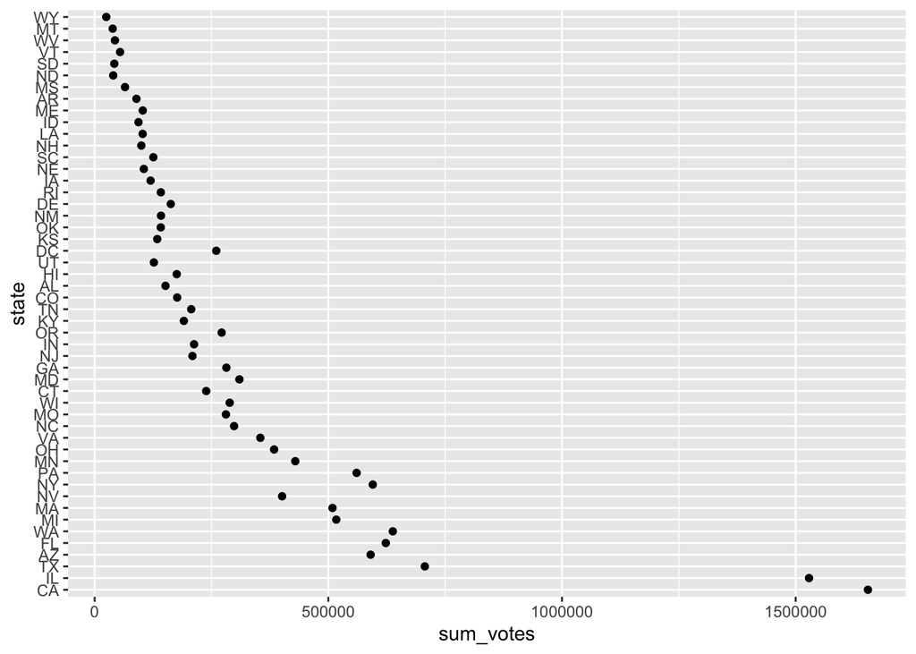

```r
election_data_w_fct %>%
  distinct(state, .keep_all = TRUE) %>%
  group_by(state) %>%
  summarize(sum_votes = sum(votes)) %>%
ggplot(aes(x = sum_votes, y = state)) +
  geom_point()
```

Two orders would make sense: alphabetical and according to their number of votes. `fct_reorder()` takes another variable and orders the factor according to it.

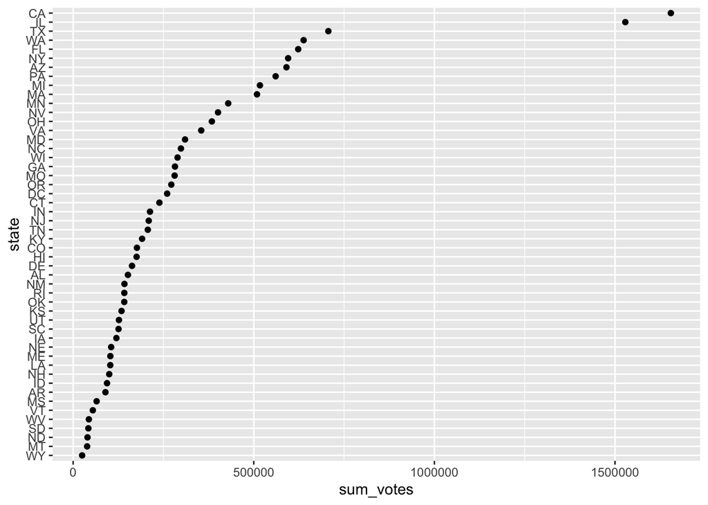

```r
election_data_w_fct %>%
  distinct(state, .keep_all = TRUE) %>%
  group_by(state) %>%
  summarize(sum_votes = sum(votes)) %>%
  mutate(state = fct_reorder(state, sum_votes)) %>%
  ggplot(aes(x = sum_votes, y = state)) +
    geom_point()
```

If you want to have it ordered the other way round, multiply the ordering variable with -1:

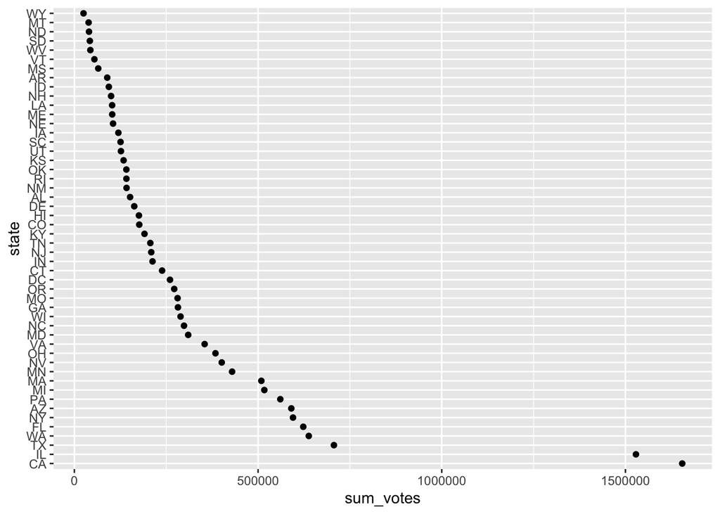

```r
election_data_w_fct %>%
  distinct(state, .keep_all = TRUE) %>%
  group_by(state) %>%
  summarize(sum_votes = sum(votes)) %>%
  mutate(state = fct_reorder(state, sum_votes*(-1))) %>%
  ggplot(aes(x = sum_votes, y = state)) +
    geom_point()
```

You could also achieve this by calling `fct_rev()` afterwards: it reverses the order of the factor.

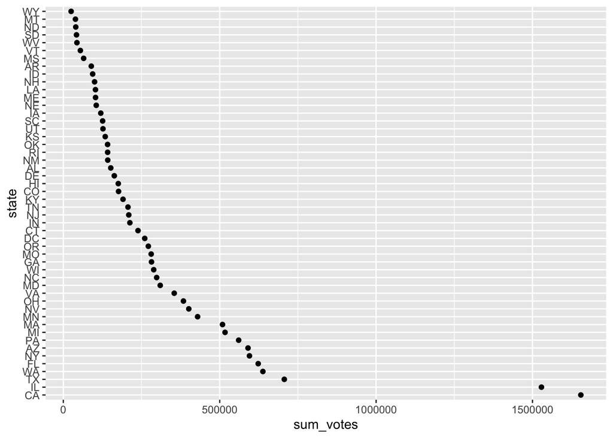

```r
election_data_w_fct %>%
  distinct(state, .keep_all = TRUE) %>%
  group_by(state) %>%
  summarize(sum_votes = sum(votes)) %>%
  mutate(state = fct_reorder(state, sum_votes),
         state = fct_rev(state)) %>%
ggplot(aes(x = sum_votes, y = state)) +
  geom_point()
```

If you want to do bar plots, which you can use to depict the frequency of a value, you can order them according to the frequency they appear in using `fct_infreq()`:

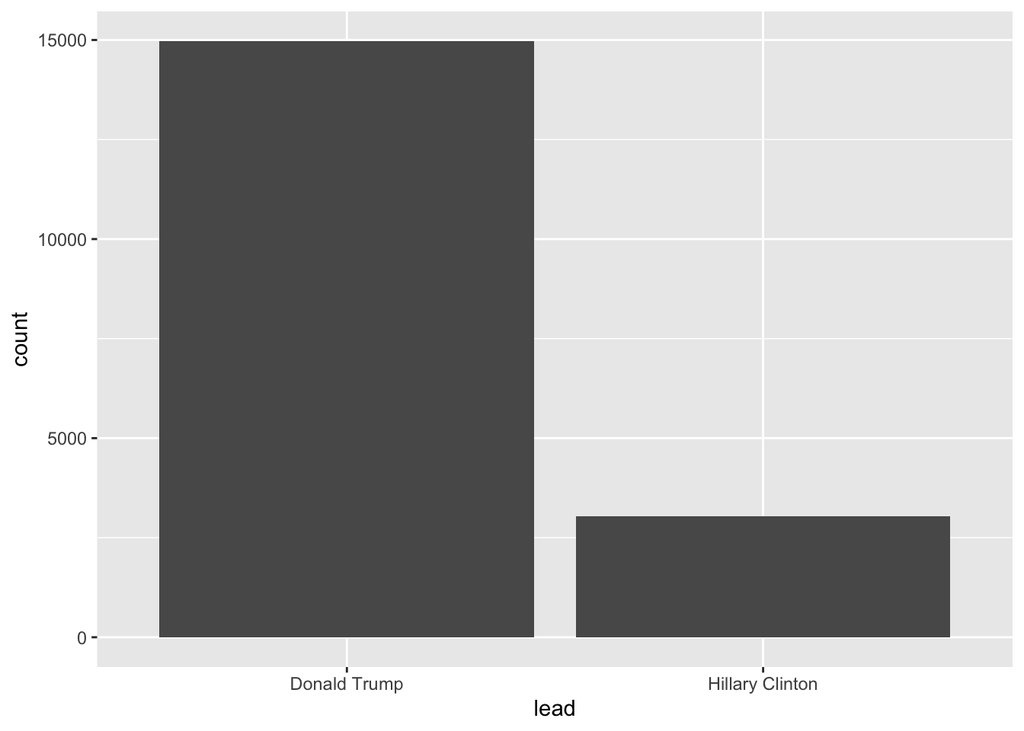

```r
election_data_w_fct %>%
  mutate(lead = lead %>% fct_infreq()) %>%
  ggplot(aes(x = lead)) +
    geom_bar()
```

## Modifying levels

```r
parties_fct_ger <- fct_recode(parties_fct,
  "Buendnis90/Die Gruenen" = "Greens",
  "Die Linke" = "Leftists"
)
```

Damn, now the levels are not in alphabetical order anymore.

```r
levels(parties_fct_ger)
```

```
## [1] "AfD"                    "CDU"                    "CSU"
## [4] "FDP"                    "Buendnis90/Die Gruenen" "Die Linke"
## [7] "SPD"
```

In this case, this can be done pretty quickly. Just copy the levels and manipulate the order:

```r
parties_fct_ger_alphabetical <- fct_relevel(parties_fct_ger,
                                            c("AfD",
                                              "Buendnis90/Die Gruenen",
                                              "CDU",
                                              "CSU",
                                              "Die Linke",
                                              "FDP",
                                              "SPD"))
levels(parties_fct_ger_alphabetical)
```

```
## [1] "AfD"                    "Buendnis90/Die Gruenen" "CDU"
## [4] "CSU"                    "Die Linke"              "FDP"
## [7] "SPD"
```

Now you need to write something for someone who is not particular familiar with the political landscape in Germany and rather wants “left,” “center,” and “right” instead of the party’s names. Give `fct_collapse()` a shot – and feel free to change it if you disagree with my classification.

```r
lcr_ger <- fct_collapse(parties_fct,
                        left = c("Leftists", "Greens", "SPD"),
                        centre = c("CDU", "CSU", "FDP"),
                        right = c("AfD"))
```

Another thing you could do – and this is handy for the election dataset – is collapsing things together according to their frequency of appearance. In the case of the election dataset, this might be handy to lump together the candidates into three groups: Donald Trump, Hillary Clinton, and other.

```r
election_data_w_fct %>%
  mutate(candidate = fct_lump(candidate, n = 2))
```

```
## # A tibble: 18,007 x 8
##    county      candidate    state pct_report  votes total_votes     pct lead
##    <fct>       <fct>        <fct>      <dbl>  <dbl>       <dbl>   <dbl> <fct>
##  1 Los Angele… Hillary Cli… CA         1     1.65e6     2314275 0.715   Hillary…
##  2 Los Angele… Donald Trump CA         1     5.43e5     2314275 0.234   Hillary…
##  3 Los Angele… Gary Johnson CA         1     5.69e4     2314275 0.0246  Hillary…
##  4 Los Angele… Other        CA         1     4.67e4     2314275 0.0202  Hillary…
##  5 Los Angele… Other        CA         1     1.35e4     2314275 0.00582 Hillary…
##  6 Cook County Hillary Cli… IL         0.975 1.53e6     2055215 0.744   Hillary…
##  7 Cook County Donald Trump IL         0.975 4.40e5     2055215 0.214   Hillary…
##  8 Cook County Gary Johnson IL         0.975 5.59e4     2055215 0.0272  Hillary…
##  9 Cook County Other        IL         0.975 3.05e4     2055215 0.0149  Hillary…
## 10 Harris Cou… Hillary Cli… TX         1     7.06e5     1302887 0.542   Hillary…
## # … with 17,997 more rows
```

```r
election_data_w_fct %>%
  mutate(candidate = fct_lump(candidate, n = 2) %>% fct_recode("Other" = "Gary Johnson"))
```

```
## # A tibble: 18,007 x 8
##    county      candidate    state pct_report  votes total_votes     pct lead
##    <fct>       <fct>        <fct>      <dbl>  <dbl>       <dbl>   <dbl> <fct>
##  1 Los Angele… Hillary Cli… CA         1     1.65e6     2314275 0.715   Hillary…
##  2 Los Angele… Donald Trump CA         1     5.43e5     2314275 0.234   Hillary…
##  3 Los Angele… Other        CA         1     5.69e4     2314275 0.0246  Hillary…
##  4 Los Angele… Other        CA         1     4.67e4     2314275 0.0202  Hillary…
##  5 Los Angele… Other        CA         1     1.35e4     2314275 0.00582 Hillary…
##  6 Cook County Hillary Cli… IL         0.975 1.53e6     2055215 0.744   Hillary…
##  7 Cook County Donald Trump IL         0.975 4.40e5     2055215 0.214   Hillary…
##  8 Cook County Other        IL         0.975 5.59e4     2055215 0.0272  Hillary…
##  9 Cook County Other        IL         0.975 3.05e4     2055215 0.0149  Hillary…
## 10 Harris Cou… Hillary Cli… TX         1     7.06e5     1302887 0.542   Hillary…
## # … with 17,997 more rows
```

# Exercise

1. `fct_reorder()` `state` alphabetically.

– No more exercises here – I save them for when we touch upon `ggplot2` –